# Bios26121: Homework 3

## Overview

Problem 1 will need to be done in a Linux environment on the RCC computing cluster. File `RNAseq_example.bam` is under /project2/bios26121/prep. Problem 2-4 can be done in any computer that have R installed.

## Problem 1: Understanding SAM files

SAMtools is a popular open-source tool used in next-generation sequence analysis. It supports many basic operations on files in a SAM format.

SAM files consist of two types of lines: headers and alignments. Headers begin with @, and provide meta-data regarding the entire alignment file. Alignments begin with any character except @, and describe a single alignment of a sequence read against the reference genome.

Two things are important to note. First, each read in a FASTQ file may align to multiple regions within a reference genome, and an individual read can therefore result in multiple alignments. In the SAM format, each of these alignments is reported on a separate line. Second, each alignment has 11 mandatory fields, followed by a variable number of optional fields. Each of the fields is described in the table below:

| **Field Name** | **Description** |
| --- | --- |
| QNAME | Unique identifier of the read; derived from the original FASTQ file. |
| FLAG | A single integer value (e.g. 16), which encodes multiple elements of meta-data regarding a read and its alignment. Elements include: whether the read is one part of a paired-end read, whether the read… |
| RNAME | Reference genome identifier. For organisms with multiple chromosomes, the RNAME is usually the chromosome number; for example, in human, an RNAME of “chr3” indicates that the read aligns to chromosome… |
| POS | Left-most position within the reference genome where the alignment occurs. |
| MAPQ | Quality of the genome mapping. The MAPQ field uses a Phred-scaled probability value to indicate the probability that the mapping to the genome is incorrect. Higher values indicate increased confidence… |
| CIGAR | A compact string that (partially) summarizes the alignment of the raw sequence read to the reference genome. Three core abbreviations are used: M for alignment match; I for insertion; and D for Deleti… |
| RNEXT | Reference genome identifier where the mate pair aligns. Only applicable when processing paired-end sequencing data. For example, an alignment with RNAME of “chr3” and RNEXT of “chr4” indicates that th… |
| PNEXT | Position with the reference genome, where the second mate pair aligns. As with RNEXT, this field is only applicable when processing paired-end sequencing data. A value of 0 indicates that information … |
| TLEN | Template Length. Only applicable for paired-end sequencing data, TLEN is the size of the original DNA or RNA fragment, determined by examining both of the paired-mates, and counting bases from the lef… |
| SEQ | The raw sequence, as originally defined in the FASTQ file. |
| QUAL | The Phred quality score for each base, as originally defined in the FASTQ file. |

#### BAM files

Normally, we work with BAM format as required by many state-of-the-art tools as input, such as IGV. A BAM file (.bam) is the binary version of a SAM file. BAM files are stored in a compressed, binary format, and cannot be viewed directly. However, you can use the same `view` command to display all alignments. For example, running:

```
module load samtools
samtools view RNAseq_example.bam | more
```

You can continue pressing space until you reach the end of the output or you can press the “q” key to exit.

Following the 11 mandatory fields, each alignment can also have a variable number of optional fields. In the example BAM files, these option fields include:

| **Field Name** | **Description** |
| --- | --- |
| AS:i:<N> | Alignment score. Can be negative. Only present if SAM record is for an aligned read. |
| ZS:i:<N> | Alignment score for the best-scoring alignment found other than the alignment reported. Can be negative. Only present if the SAM record is for an aligned read and more than one alignment was found for… |
| YS:i:<N> | Alignment score for opposite mate in the paired-end alignment. Only present if the SAM record is for a read that aligned as part of a paired-end alignment. |

and others. For the rest, please check https://ccb.jhu.edu/software/hisat2/manual.shtml#sam-output.

#### Questions:

- Run `samtools view -H RNAseq_example.bam` to inspect the headers. Read Section 1.3 in https://samtools.github.io/hts-specs/SAMv1.pdf and answer:
  1. Is this file sorted?
  2. What is the length of reference sequence on “chr17”?
- Run `samtools help view` in the console to obtain the help page for `samtools view` command. Using `RNAseq_example.bam`, answer the following questions:
  1. What is the option to filter the reads based on mapping quality?
  2. Can you write a command to extract reads with a mapping quality greater than 10?
  3. `samtools view RNAseq_example.bam | head -n 10` will print first ten alignments. What is the 20th alignment in `RNAseq_example.bam`?
  4. Create an index for `RNAseq_example.bam` using `samtools index RNAseq_example.bam`. `samtools view RNAseq_example.bam "chr10:4360000-4455000"` will give you all the alignments within a given region, in this example, 4360000-4455000 on chromosome 10. What is command to extract reads that fall within 92152000-92350000 on chromosome 5 and save to a new BAM file `RNAseq_example_region.bam`? What is the 5th alignment in `RNAseq_example_region.bam`? Is it a perfect match alignment?

## Problem 2: Quantile normalization implementation

- In statistics, quantile normalization is a technique for making two distributions identical in statistical properties. To quantile normalize two or more distributions to each other, without a reference distribution, sort as before, then set to the average (usually, arithmetical mean) of the distributions. It has the following steps, given a matrix with rows as features and columns as samples:
  1. Determine the ranks of each column from lowest to highest;
  2. Sort the original matrix from lowest to highest;
  3. Calculate the means and substitute the means into our ranked matrix.
- We demonstrate the procedure implemented in R as follows:

  ```r
  # create a toy example:
  df <- data.frame(one=c(5,2,3,4),
               two=c(4,1,4,2),
               three=c(3,4,6,8)
               )
  rownames(df) <- toupper(letters[1:4])

  # Determine the ranks of each column from lowest to highest:
  df_rank <- apply(df,2,rank,ties.method="min")

  #Sort the original matrix from lowest to highest;
  df_sorted <- data.frame(apply(df, 2, sort))

  #Calculate the means:
  df_mean <- apply(df_sorted, 1, mean)

  #Finally substitute the means into our ranked matrix:
  index_to_mean <- function(my_index, my_mean){
    return(my_mean[my_index])
  }

  df_final <- apply(df_rank, 2, index_to_mean, my_mean=df_mean)
  rownames(df_final) <- toupper(letters[1:4])
  ```

#### Questions:

- Run the code above and report output of each step. Answer:
  1. In the function `rank` , `ties.method=` is used to specify how ties are treated. Will the results be the same if we use `"random"` or `"average"`? You can obtain documentation of `rank` function by running `?rank` in the console. With the increasing number of samples and features, will the choice of `ties.method` be increasingly important? Why?
  2. In the function `sort` , we can use `decreasing=` to specify should the sort be increasing or decreasing. The default setting is `decreasing=FALSE`. If we set `decreasing=TRUE`, does it have effects on the result?
- The `preprocessCore` package on Bioconductor already has a function for quantile normalization, called `normalize.quantiles`. Can you use that function to perform quantile normalization on the previous toy example? Do you get same results? Why or why not?

  ```r
  #install if necessary
  source('http://bioconductor.org/biocLite.R')
  biocLite('preprocessCore')
  #load package
  ```

  ```r
  #load data
  library(preprocessCore)
  library("Biobase")
  load("normalization_example.RData")
  mp = montpick.eset
  pdata=pData(mp)
  edata=as.data.frame(exprs(mp))
  fdata = fData(mp)
  ls()

  #show distributions for log2 counts for several samples
  edata = log2(edata + 1)
  edata = edata[rowMeans(edata) > 3, ]
  colramp = colorRampPalette(c(3,"white",2))(20)
  plot(density(edata[,1]),col=colramp[1],lwd=3,ylim=c(0,.30))
  for(i in 2:20){lines(density(edata[,i]),lwd=3,col=colramp[i])}
  ```

  - Apply `normalize.quantiles` in `preprocessCore` package to perform quantile normalization on data matrix `edata`? Can you make a density plot for normalized samples? Compare with density before normalization, what do you see?
  - Apply `MedianNorm` in `EBSeq` package to perform median-by-ratio normalization on data matrix `edata`? Can you make a density plot for normalized samples? Compare with density normalized by quantiles, what do you see? What is the advantage of median-by-ratio normalization?

## Problem 3: Batch effect

## Dependencies

This document depends on the following packages:

```r
  library(devtools)
  library(Biobase)
  library(sva)
  library(bladderbatch)
  library(snpStats)
  library(factoextra)
```

To install these packages you can use the code (or if you are compiling the document, remove the `eval=FALSE` from the chunk.)

```r
install.packages(c("devtools","factoextra"))
source("http://www.bioconductor.org/biocLite.R")
biocLite(c("Biobase","sva","bladderbatch","snpStats"))
```

## Download the data

The analyses performed in this experiment are based on gene expression measurements from a bladder cancer study: [Gene expression in the urinary bladder: a common carcinoma in situ gene expression signature exists disregarding histopathological classification.](http://cancerres.aacrjournals.org/content/64/11/4040.full.pdf) The data can be loaded from the [bladderbatch](http://bioconductor.org/packages/release/data/experiment/html/bladderbatch.html) data package.

```r
data(bladderdata)
```

## Set up the data

```r
pheno = pData(bladderEset)
edata = exprs(bladderEset)
colnames(edata) <- gsub(".CEL", "", colnames(edata))
colnames(edata) <- paste0("B", pheno$batch, "_", colnames(edata))
table(pheno$batch, pheno$outcome)
```

```
##
##     Biopsy mTCC Normal sTCC-CIS sTCC+CIS
##   1      0   11      0        0        0
##   2      0    1      4       13        0
##   3      0    0      4        0        0
##   4      5    0      0        0        0
##   5      4    0      0        3       12
```

## Perform PCA

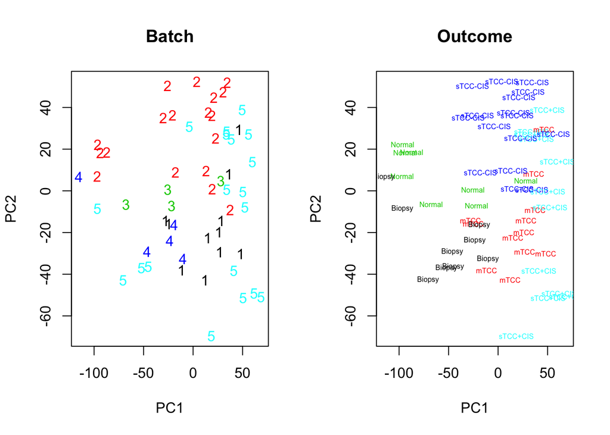

```r
resPC <-  prcomp(t(edata))
batch.id <- pheno$batch
outcome <- pheno$outcome


PC1 <- resPC$x[, 1]
PC2 <- resPC$x[, 2]


par(mfrow = c(1, 2))
plot(PC1, PC2, type = "n", main = "Batch")
text(PC1, PC2, batch.id, col = batch.id, cex = 1)


plot(PC1, PC2, type = "n", main = "Outcome")
text(PC1, PC2, outcome, col = as.numeric(as.factor(outcome)), cex = 0.5)
```

## Perform hierarchical clustering

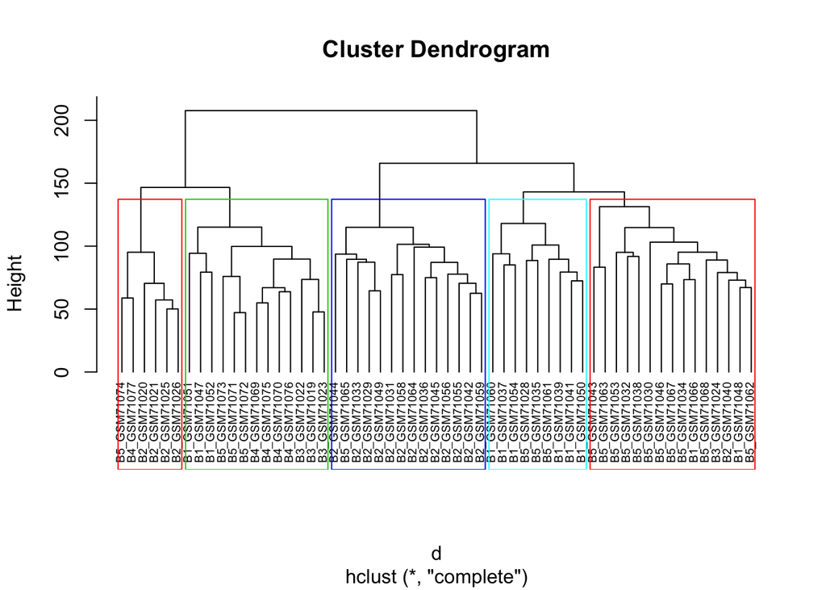

```r
d <- dist(t(edata), method = "euclidean")

# Hierarchical clustering using Complete Linkage
hc1 <- hclust(d, method = "complete" )

# Plot the obtained dendrogram
plot(hc1, cex = 0.6, hang = -1)
rect.hclust(hc1, k = 5, border = 2:5)
```

## Visualze the clustering results in a scatter plot

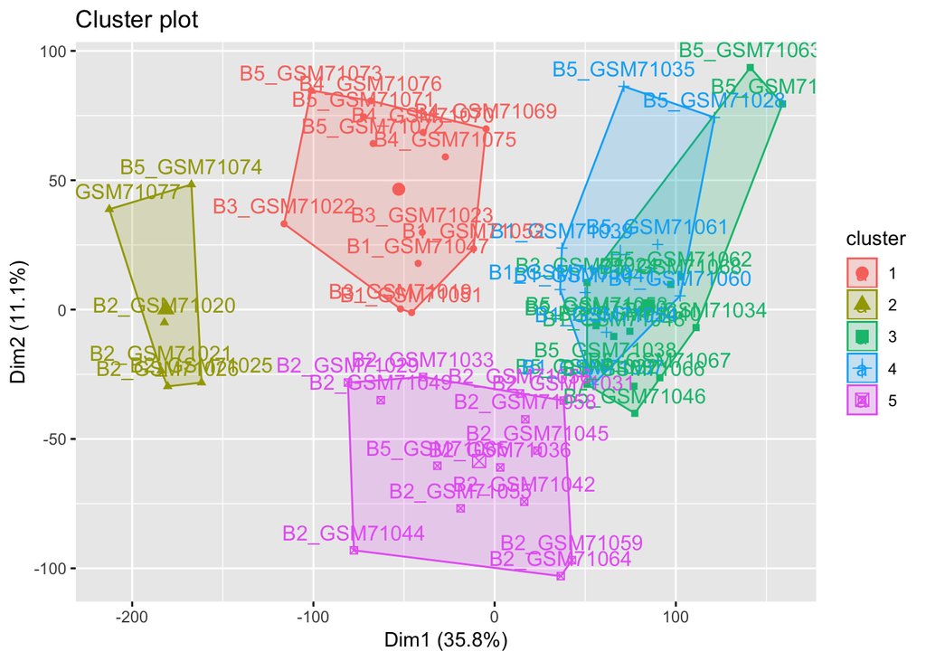

```r
sub_grp <- cutree(hc1, k = 5)
fviz_cluster(list(data = t(edata), cluster = sub_grp))
```

#### Questions:

- Run the code above and report output of each step. Answer:
  1. Can you make comments on the experimental design based on the table of batch and outcome? Any problems? How can you improve the design?
  2. By looking at PCA, do you observe batch effects in this dataset? Why or why not?
  3. When only looking at the above hierarchical clustering results, can you make judgements on the batch effects? If not, what esle analysis do you need to do?

## Problem 4: Techinical Variability Vs. Biological Variability

## Introduction

In the following sections we will cover inference in the context of genomics experiments. Here we introduce a concept that is particularly important in the analysis of genomics data: the distinction between biological and technical variability.

In general, the variability we observe across biological units, such as individuals, within a population is referred to as **biological**. We refer to the variability we observe across measurements of the same biological unit, such a aliquots from the same biological sample, as **technical**. Because newly developed measurement technologies are common in genomics, technical replicates are used many times to assess experimental data. By generating measurements from samples that are designed to be the same, we are able to measure and assess technical variability. We also use the terminology **biological replicates** and **technical replicates** to refer to samples from which we can measure biological and technical variability respectively.

It is important not to confuse biological and technical variability when performing statistical inference as the interpretation is quite different. For example, when analyzing data from technical replicates, the population is just the one sample from which these come from as opposed to more general population such as healthy humans or control mice. Here we explore this concept with a experiment that was designed to include both technical and biological replicates.

## Pooling experiment data

The dataset we will study includes data from gene expression arrays. In this experiment, RNA was extracted from 12 randomly selected mice from two strains. All 24 samples were hybridized to microarrays but we also formed pools, including two pools from with the RNA from all twelve mice from each of the two strains. Other pools were also created, as we will see below, but we will ignore these here.

We will need the following library which you need to install if you have not done so already:

```r
library(devtools)
install_github("genomicsclass/maPooling")
install_github("ririzarr/rafalib")
```

We can see the experimental design using the `pData` function. Each row represents a sample and the column are the mice. A 1 in cell $i,j$ indicates that RNA from mouse $j$ was included in sample $i$. The strain can be identified from the row names (this is not a recommended approach, you can add additional variables to the phenoData to make strain information explicit.)

```r
library(Biobase)
library(maPooling)
data(maPooling)
head(pData(maPooling))
```

```
##          a2 a3 a4 a5 a6 a7 a8 a9 a10 a11 a12 a14 b2 b3 b5 b6 b8 b9 b10 b11
## a10       0  0  0  0  0  0  0  0   1   0   0   0  0  0  0  0  0  0   0   0
## a10a11    0  0  0  0  0  0  0  0   1   1   0   0  0  0  0  0  0  0   0   0
## a10a11a4  0  0  1  0  0  0  0  0   1   1   0   0  0  0  0  0  0  0   0   0
## a11       0  0  0  0  0  0  0  0   0   1   0   0  0  0  0  0  0  0   0   0
## a12       0  0  0  0  0  0  0  0   0   0   1   0  0  0  0  0  0  0   0   0
## a12a14    0  0  0  0  0  0  0  0   0   0   1   1  0  0  0  0  0  0   0   0
##          b12 b13 b14 b15
## a10        0   0   0   0
## a10a11     0   0   0   0
## a10a11a4   0   0   0   0
## a11        0   0   0   0
## a12        0   0   0   0
## a12a14     0   0   0   0
```

Below we create an image to illustrate which mice were included in which samples:

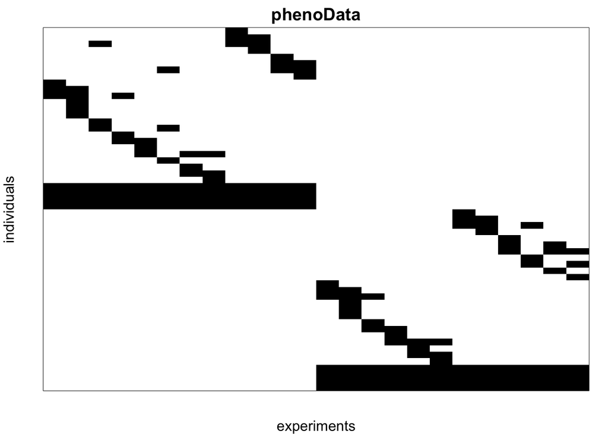

```r
library(rafalib)
mypar()
flipt <- function(m) t(m[nrow(m):1,])
myimage <- function(m,...) {
  image(flipt(m),xaxt="n",yaxt="n",...)
  }
myimage(as.matrix(pData(maPooling)),col=c("white","black"),
        xlab="experiments",
        ylab="individuals",
        main="phenoData")
```

Note that ultimately we are interested in detecting genes that are differentially expressed between the two strains of mice which we will refer to as strain 0 and 1. We can apply tests to the technical replicates of pooled samples or the data from 12 individual mice. We can identify these pooled samples because all mice from each strain were represented in these samples and thus the sum of the rows of experimental design matrix add up to 12:

```r
data(maPooling)
pd=pData(maPooling)
pooled=which(rowSums(pd)==12)
```

We can determine the strain from the column names:

```r
factor(as.numeric(grepl("b",names(pooled))))
```

```
## [1] 0 0 0 0 1 1 1 1
## Levels: 0 1
```

If we compare the mean expression between groups for each gene we find several showing consistent differences. Here are two examples:

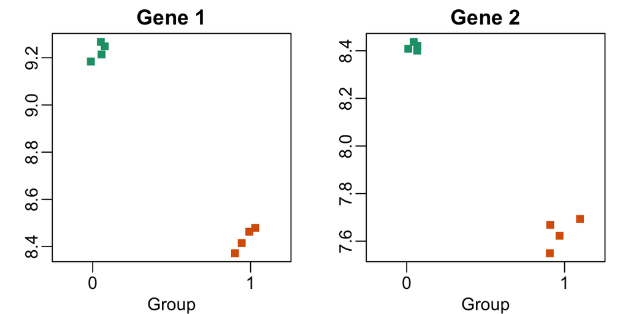

```r
###look at 2 pre-selected genes for illustration
i=11425;j=11878
pooled_y=exprs(maPooling[,pooled])
pooled_g=factor(as.numeric(grepl("b",names(pooled))))
mypar(1,2)
stripchart(split(pooled_y[i,],pooled_g),vertical=TRUE,method="jitter",col=c(1,2),
           main="Gene 1",xlab="Group",pch=15)
stripchart(split(pooled_y[j,],pooled_g),vertical=TRUE,method="jitter",col=c(1,2),
           main="Gene 2",xlab="Group",pch=15)
```

Note that if we compute a t-test from these values we obtain highly significant results

```r
library(genefilter)
pooled_tt=rowttests(pooled_y,pooled_g)
pooled_tt$p.value[i]
```

```
## [1] 2.075617e-07
```

```r
pooled_tt$p.value[j]
```

```
## [1] 3.400476e-07
```

Observe that what is being replicated here is the experimental protocol. We have created four **technical replicates** for each pooled sample. Gene 1 may be a highly variable gene within strain of mice while Gene 2 a stable one, but we have no way of seeing this, because mouse-to-mouse variability is submerged in the act of pooling.

We also have microarray data for each individual mouse. For each strain we have 12 **biological replicates**. We can find them by looking for rows with just one 1.

```r
individuals=which(rowSums(pd)==1)
```

It turns out that some technical replicates were included for some individual mice so we remove them to illustrate an analysis with only biological replicates:

```r
##remove replicates
individuals=individuals[-grep("tr",names(individuals))]
y=exprs(maPooling)[,individuals]
g=factor(as.numeric(grepl("b",names(individuals))))
```

We can compute the sample variance for each gene and compare to the standard deviation obtained with the technical replicates.

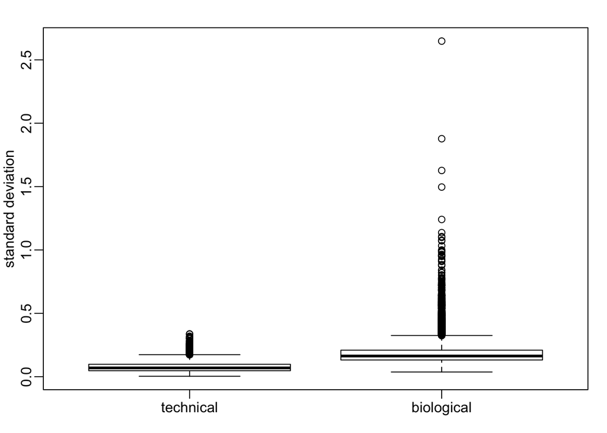

```r
technicalsd <- rowSds(pooled_y[,pooled_g==0])
biologicalsd <- rowSds(y[,g==0])
LIM=range(c(technicalsd,biologicalsd))
mypar(1,1)
boxplot(technicalsd,biologicalsd,names=c("technical","biological"),ylab="standard deviation")
```

Note the biological variance is much larger than the technical variance. And also that the variability of variances is also larger for biological variance. Here are the two genes we showed above but now we show expression values measured on each individual mouse

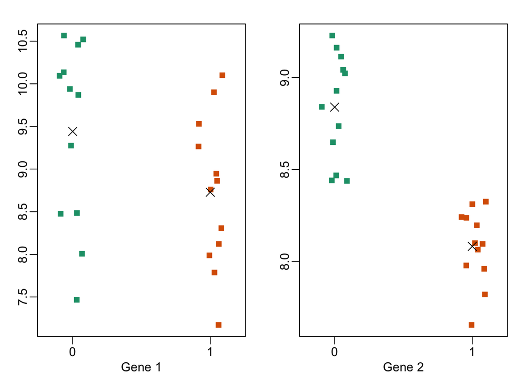

```r
mypar(1,2)
stripchart(split(y[i,],g),vertical=TRUE,method="jitter",col=c(1,2),xlab="Gene 1",pch=15)
points(c(1,2),tapply(y[i,],g,mean),pch=4,cex=1.5)
stripchart(split(y[j,],g),vertical=TRUE,method="jitter",col=c(1,2),xlab="Gene 2",pch=15)
points(c(1,2),tapply(y[j,],g,mean),pch=4,cex=1.5)
```

Now the p-values tell a different story

```r
library(genefilter)
tt=rowttests(y,g)
tt$p.value[i]
```

```
## [1] 0.0898726
```

```r
tt$p.value[j]
```

```
## [1] 1.979172e-07
```

#### Questions:

- Read the context and run the code above. Answer:
  1. What does the biolgical and technical variability mean in this example?
  2. Which of these two genes do we feel more confident reporting as being differentially expressed between strains?
  3. If another investigator takes another random sample of mice and tries the same experiment, which gene do you think will be identified?

## Reference

This homework contains online materials written by Rafael Irizarry, Jeef Leek, Ethan Cerami, Dave Tang.